# AmazonLSTM

```python
# Code to read csv file into Colaboratory:
!pip install -U -q PyDrive
from pydrive.auth import GoogleAuth
from pydrive.drive import GoogleDrive
from google.colab import auth
from oauth2client.client import GoogleCredentials
# Authenticate and create the PyDrive client.
auth.authenticate_user()
gauth = GoogleAuth()
gauth.credentials = GoogleCredentials.get_application_default()
drive = GoogleDrive(gauth)
```

```python
link='https://drive.google.com/open?id=1Ep6BVj98I3IoNrLgn8jhCCNbM66-IvUC'
```

```python
fluff, id = link.split('=')
print(id) # Verify that you have everything after '='
```

```
1Ep6BVj98I3IoNrLgn8jhCCNbM66-IvUC
```

```python
import pandas as pd
downloaded = drive.CreateFile({'id':id})
downloaded.GetContentFile('Reviews.csv')
```

# [7] Amazon Fine Food Reviews Analysis

Data Source: https://www.kaggle.com/snap/amazon-fine-food-reviews

The Amazon Fine Food Reviews dataset consists of reviews of fine foods from Amazon.

Number of reviews: 568,454  
Number of users: 256,059  
Number of products: 74,258  
Timespan: Oct 1999 - Oct 2012  
Number of Attributes/Columns in data: 10

Attribute Information:

1. Id
2. ProductId - unique identifier for the product
3. UserId - unqiue identifier for the user
4. ProfileName
5. HelpfulnessNumerator - number of users who found the review helpful
6. HelpfulnessDenominator - number of users who indicated whether they found the review helpful or not
7. Score - rating between 1 and 5
8. Time - timestamp for the review
9. Summary - brief summary of the review
10. Text - text of the review

#### Objective:

Given a review, determine whether the review is positive (Rating of 4 or 5) or negative (rating of 1 or 2).

[Q] How to determine if a review is positive or negative?  
[Ans] We could use the Score/Rating. A rating of 4 or 5 could be cosnidered a positive review. A review of 1 or 2 could be considered negative. A review of 3 is nuetral and ignored. This is an approximate and proxy way of determining the polarity (positivity/negativity) of a review.

```python
%matplotlib inline
import warnings
warnings.filterwarnings("ignore")

import sqlite3
import pandas as pd
import numpy as np
import nltk
import string
from collections import Counter
import matplotlib.pyplot as plt
import seaborn as sns
from sklearn.feature_extraction.text import TfidfTransformer
from sklearn.feature_extraction.text import TfidfVectorizer

from sklearn.feature_extraction.text import CountVectorizer
from sklearn.metrics import confusion_matrix,accuracy_score, classification_report
from sklearn import metrics
from sklearn.metrics import roc_curve, auc
from nltk.stem.porter import PorterStemmer

import re
# Tutorial about Python regular expressions: https://pymotw.com/2/re/
import string
from nltk.corpus import stopwords
from nltk.stem import PorterStemmer
from nltk.stem.wordnet import WordNetLemmatizer

from gensim.models import Word2Vec
from gensim.models import KeyedVectors
import pickle

from tqdm import tqdm
import os

import numpy
from sklearn.model_selection import train_test_split
from keras.models import Sequential
from keras.layers import Dense,Dropout,LSTM,BatchNormalization
from keras.layers.embeddings import Embedding
from keras.preprocessing import sequence
```

```python
df= pd.read_csv("Reviews.csv")
df.head()
```

|  | Id | ProductId | UserId | ProfileName | HelpfulnessNumerator | HelpfulnessDenominator | Score | Time | Summary | Text |
| --- | --- | --- | --- | --- | --- | --- | --- | --- | --- | --- |
| 0 | 1 | B001E4KFG0 | A3SGXH7AUHU8GW | delmartian | 1 | 1 | 5 | 1303862400 | Good Quality Dog Food | I have bought several of the Vitality canned d... |
| 1 | 2 | B00813GRG4 | A1D87F6ZCVE5NK | dll pa | 0 | 0 | 1 | 1346976000 | Not as Advertised | Product arrived labeled as Jumbo Salted Peanut... |
| 2 | 3 | B000LQOCH0 | ABXLMWJIXXAIN | Natalia Corres "Natalia Corres" | 1 | 1 | 4 | 1219017600 | "Delight" says it all | This is a confection that has been around a fe... |
| 3 | 4 | B000UA0QIQ | A395BORC6FGVXV | Karl | 3 | 3 | 2 | 1307923200 | Cough Medicine | If you are looking for the secret ingredient i... |
| 4 | 5 | B006K2ZZ7K | A1UQRSCLF8GW1T | Michael D. Bigham "M. Wassir" | 0 | 0 | 5 | 1350777600 | Great taffy | Great taffy at a great price. There was a wid... |

```python
#filtering only positive and negative reviews i.e.
# not taking into consideration those reviews with Score=3
filtered_data = df[df['Score'] != 3]

# Give reviews with Score>3 a positive rating, and reviews with a score<3 a negative rating.
def partition(x):
    if x < 3:
        return 0
    return 1

#changing reviews with score less than 3 to be positive and vice-versa
filtered_data['Score'] = filtered_data['Score'].map(partition)
```

```python
#  Exploratory Data Analysis

## [7.1.2] Data Cleaning: Deduplication

#It is observed (as shown in the table below) that the reviews data had many duplicate entries. Hence it was necessary to remove duplicates in order to get unbiased results for the analysis of the data.  Following is an example:

#Sorting data according to ProductId in ascending order
sorted_data=filtered_data.sort_values('ProductId', axis=0, ascending=True, inplace=False, kind='quicksort', na_position='last')

#Deduplication of entries
final=sorted_data.drop_duplicates(subset={"UserId","ProfileName","Time","Text"}, keep='first', inplace=False)

# Removing rows where HelpfulnessNumerator is greater than HelpfulnessDenominator
final = final[final.HelpfulnessNumerator <= final.HelpfulnessDenominator]

#Checking to see how much % of data still remains
(final['Id'].size*1.0)/(filtered_data['Id'].size*1.0)*100

#Before starting the next phase of preprocessing lets see the number of entries left
print(final.shape)

#How many positive and negative reviews are present in our dataset?
final['Score'].value_counts()
```

[output not shown]

```
(364171, 10)
```

```
1    307061
0     57110
Name: Score, dtype: int64
```

## 7.2.3 Text Preprocessing: Stemming, stop-word removal and Lemmatization.

Now that we have finished deduplication our data requires some preprocessing before we go on further with analysis and making the prediction model.

Hence in the Preprocessing phase we do the following in the order below:-

1. Begin by removing the html tags
2. Remove any punctuations or limited set of special characters like , or . or # etc.
3. Check if the word is made up of english letters and is not alpha-numeric
4. Check to see if the length of the word is greater than 2 (as it was researched that there is no adjective in 2-letters)
5. Convert the word to lowercase
6. Remove Stopwords
7. Finally Snowball Stemming the word (it was obsereved to be better than Porter Stemming)

After which we collect the words used to describe positive and negative reviews

```python
import nltk
nltk.download('stopwords')
# find sentences containing HTML tags
import re
i=0;
for sent in final['Text'].values:
    if (len(re.findall('<.*?>', sent))):
        print(i)
        print(sent)
        break;
    i += 1;
stop = set(stopwords.words('english')) #set of stopwords
sno = nltk.stem.SnowballStemmer('english') #initialising the snowball stemmer

def cleanhtml(sentence): #function to clean the word of any html-tags
    cleanr = re.compile('<.*?>')
    cleantext = re.sub(cleanr, ' ', sentence)
    return cleantext
def cleanpunc(sentence): #function to clean the word of any punctuation or special characters
    cleaned = re.sub(r'[?|!|\'|"|#]',r'',sentence)
    cleaned = re.sub(r'[.|,|)|(|\|/]',r' ',cleaned)
    return  cleaned
print(stop)
print('************************************')
print(sno.stem('tasty'))
```

```
6
I set aside at least an hour each day to read to my son (3 y/o). At this point, I consider myself a connoisseur of children's books and this is one of the best. Santa Clause put this under the tree. Since then, we've read it perpetually and he loves it.<br /><br />First, this book taught him the mon…
{"shouldn't", 'down', 'their', 'isn', 'when', 'by', 'we', 'having', "doesn't", 'hasn', "weren't", "wouldn't", 'yours', 'or', "you've", 'should', 'shouldn', 'it', 'which', 'but', 'own', 'wasn', 'weren', 'had', 'too', 'again', 'after', 'll', 'more', 'against', 'y', 'very', "needn't", 'not', 'as', 'dur…
tasti
```

```python
#Code for implementing step-by-step the checks mentioned in the pre-processing phase
# this code takes a while to run as it needs to run on 500k sentences.
#if not os.path.isfile('final.sqlite'):
i=0
str1=' '
final_string=[]
all_positive_words=[] # store words from +ve reviews here
all_negative_words=[] # store words from -ve reviews here.
s=''
for sent in tqdm(final['Text'].values):
    filtered_sentence=[]
    #print(sent);
    sent=cleanhtml(sent) # remove HTMl tags
    for w in sent.split():
        for cleaned_words in cleanpunc(w).split():
            if((cleaned_words.isalpha()) & (len(cleaned_words)>2)):
                if(cleaned_words.lower() not in stop):
                    s=(sno.stem(cleaned_words.lower())).encode('utf8')
                    filtered_sentence.append(s)
                    if (final['Score'].values)[i] == 1:
                        all_positive_words.append(s) #list of all words used to describe positive reviews
                    if(final['Score'].values)[i] == 0:
                        all_negative_words.append(s) #list of all words used to describe negative reviews reviews
                else:
                    continue
            else:
                continue
    #print(filtered_sentence)
    str1 = b" ".join(filtered_sentence) #final string of cleaned words
    #print("***********************************************************************")

    final_string.append(str1)
    i+=1

final['CleanedText']=final_string #adding a column of CleanedText which displays the data after pre-processing of the review
final['CleanedText']=final['CleanedText'].str.decode("utf-8")
```

```python
cleaned_text = final['CleanedText'].values

all_words=[]
for sentence in cleaned_text:
    words = sentence.split()
    all_words += words
print("Number of words present in Cleaned dataset :",len(all_words))
word_counts = Counter(all_words)
print("Unique no. of words present in the dataset: ",len(word_counts.most_common()))
vocab = len(word_counts.most_common())+1
# load the dataset but only keep the top  words, zero the rest
top_words = 6000
sorted_words = word_counts.most_common(top_words)
check = dict()
i = 1
for word,_ in sorted_words:
    check[word] = i
    i += 1
```

```
Number of words present in Cleaned dataset : 13964992
Unique no. of words present in the dataset:  71626
```

```python
def get_word_index(row):
    index = []
    for word in row['CleanedText'].split():
        if word in check:
            index.append(check[word])
        else:
            index.append(0)
    return index

final['CleanedText_WordCount'] = final.apply(lambda row: get_word_index(row),axis=1)
final.head()
```

|  | Id | ProductId | UserId | ProfileName | HelpfulnessNumerator | HelpfulnessDenominator | Score | Time | Summary | Text | CleanedText | CleanedText_WordCount |
| --- | --- | --- | --- | --- | --- | --- | --- | --- | --- | --- | --- | --- |
| 150523 | 150524 | 0006641040 | ACITT7DI6IDDL | shari zychinski | 0 | 0 | 1 | 939340800 | EVERY book is educational | this witty little book makes my son laugh at l... | witti littl book make son laugh loud recit car... | [0, 28, 1082, 14, 369, 2405, 3182, 0, 1117, 12... |
| 150505 | 150506 | 0006641040 | A2IW4PEEKO2R0U | Tracy | 1 | 1 | 1 | 1194739200 | Love the book, miss the hard cover version | I grew up reading these Sendak books, and watc... | grew read sendak book watch realli rosi movi i... | [1035, 232, 0, 1082, 661, 19, 0, 1215, 2701, 8... |
| 150506 | 150507 | 0006641040 | A1S4A3IQ2MU7V4 | sally sue "sally sue" | 1 | 1 | 1 | 1191456000 | chicken soup with rice months | This is a fun way for children to learn their ... | fun way children learn month year learn poem t... | [694, 61, 826, 793, 130, 44, 793, 0, 1414, 100... |
| 150507 | 150508 | 0006641040 | AZGXZ2UUK6X | Catherine Hallberg "(Kate)" | 1 | 1 | 1 | 1076025600 | a good swingy rhythm for reading aloud | This is a great little book to read aloud- it ... | great littl book read nice rhythm well good re... | [9, 28, 1082, 232, 69, 0, 34, 4, 0, 28, 7, 1, ... |
| 150508 | 150509 | 0006641040 | A3CMRKGE0P909G | Teresa | 3 | 4 | 1 | 1018396800 | A great way to learn the months | This is a book of poetry about the months of t... | book poetri month year goe month cute littl po... | [1082, 0, 130, 44, 431, 130, 1419, 28, 0, 543,... |

```python
# https://gist.github.com/greydanus/f6eee59eaf1d90fcb3b534a25362cea4
# https://stackoverflow.com/a/14434334
# this function is used to update the plots for each epoch and error
plt.rcParams['axes.facecolor'] = 'white'
def plt_dynamic(x, vy, ty):
    plt.figure(figsize=(20,10))
    plt.plot(x, vy, 'b', label="Validation Loss")
    plt.plot(x, ty, 'r', label="Train Loss")
    plt.xlabel("Epochs")
    plt.ylabel("Binary Crossentropy Loss")
    plt.title("Binary Crossentropy Loss Vs Epochs")
    plt.legend()
    plt.grid(c='grey')
    plt.show()
```

```python
# Split data into train and test
X_train, X_test, y_train, y_test = train_test_split(final['CleanedText_WordCount'].values,final['Score'],test_size=0.3,shuffle=False,random_state=42)

print(X_train.shape[0], 'train samples')
print(X_test.shape[0], 'test samples')

# truncate and/or pad input sequences
max_review_length = 600
X_train = sequence.pad_sequences(X_train, maxlen=max_review_length)
X_test = sequence.pad_sequences(X_test, maxlen=max_review_length)
```

```
254919 train samples
109252 test samples
```

## RNN 1 LSTM Layer

```python
# create the model
embedding_vecor_length = 32
batch_size = 128
epochs = 6
model_1 = Sequential([
Embedding(vocab, embedding_vecor_length, input_length=max_review_length),
Dropout(0.3),
LSTM(100),
Dense(1, activation='sigmoid'),
])
# Model Summary
model_1.summary()
# Compiling the Model
model_1.compile(loss='binary_crossentropy', optimizer='adam', metrics=['accuracy'])

history_1=model_1.fit(X_train, y_train,batch_size=batch_size,epochs=epochs,verbose=1,validation_data=(X_test, y_test))
```

```
_________________________________________________________________
Layer (type)                 Output Shape              Param #
=================================================================
embedding_1 (Embedding)      (None, 600, 32)           2292064
_________________________________________________________________
dropout_1 (Dropout)          (None, 600, 32)           0
_________________________________________________________________
lstm_1 (LSTM)                (None, 100)               53200
_________________________________________________________________
dense_1 (Dense)              (None, 1)                 101
=================================================================
Total params: 2,345,365
Trainable params: 2,345,365
Non-trainable params: 0
_________________________________________________________________
Train on 254919 samples, validate on 109252 samples
```

```
Test score: 0.1818962852349085
Test accuracy: 92.81203090103614
Train accuracy: 94.18638861800513
```

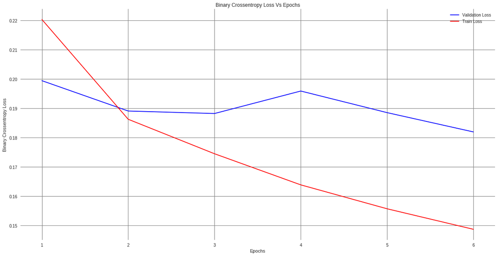

```python
# Evaluating the model
score = model_1.evaluate(X_test, y_test, verbose=0)
print('Test score:', score[0])
print('Test accuracy:', score[1]*100)

# Test and train accuracy of the model
model_1_test = score[1]
model_1_train = history_1.history['acc']
print('Train accuracy:', model_1_train[5]*100)

# Plotting Train and Test Loss VS no. of epochs
# list of epoch numbers
x = list(range(1,epochs+1))

# Validation loss
vy = history_1.history['val_loss']
# Training loss
ty = history_1.history['loss']

# PLot Function for Loss vs Epochs
plt_dynamic(x, vy, ty)
```